# Risk Report

## Tuberculosis

The first part of the assignment uses the **BCG** dataset from the **HSAUR** package. It contains the results from 13 different studies that assess the effectiveness of the Bacillus Calmette–Guérin vaccine in preventing Tuberculosis.

> The histogram below represents the distribution of the odds ratios over all 13 studies. This shows that for 11 out of the 13 cases the odds of a TB patient not being vaccinated was more than the odds of a TB patient who got vaccinated.

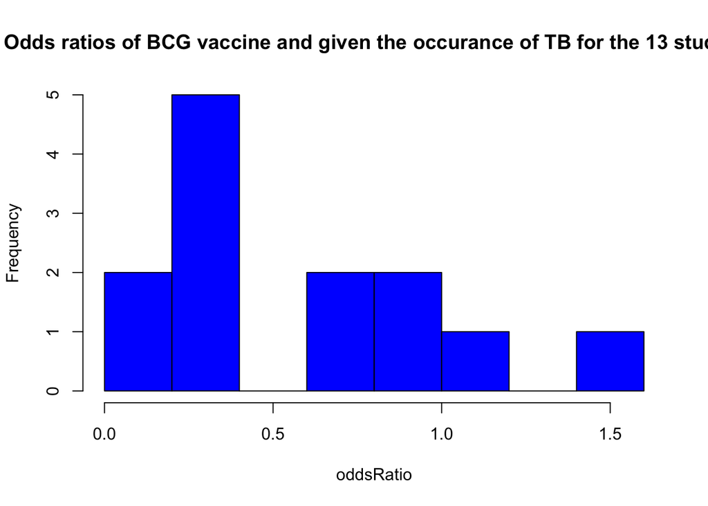

**Relationship between Odds Ratios and Years**

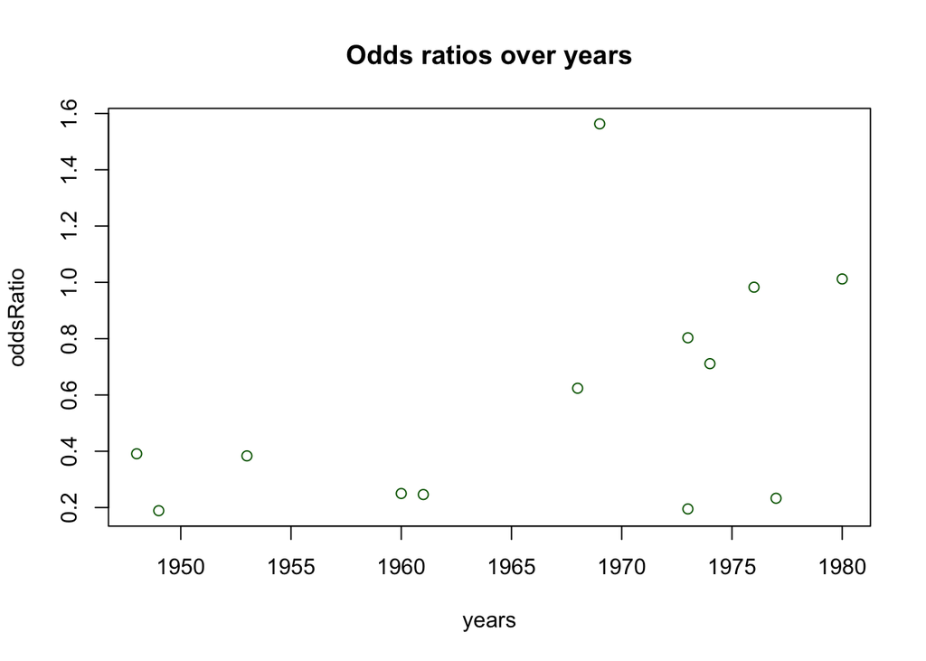

> In this graph, we can see a positive relation between time and odds ratios, with a few outliers. That is, over time, the odds of a TB patient being vaccinated has increased. This might mean that the effectiveness of the vaccine is decreasing. In around 1970, there was the odds ratio is much higher than the other entries. This might be because of a TB outbreak durng that time.

**Relationship between Odds Ratios and Latitudes**

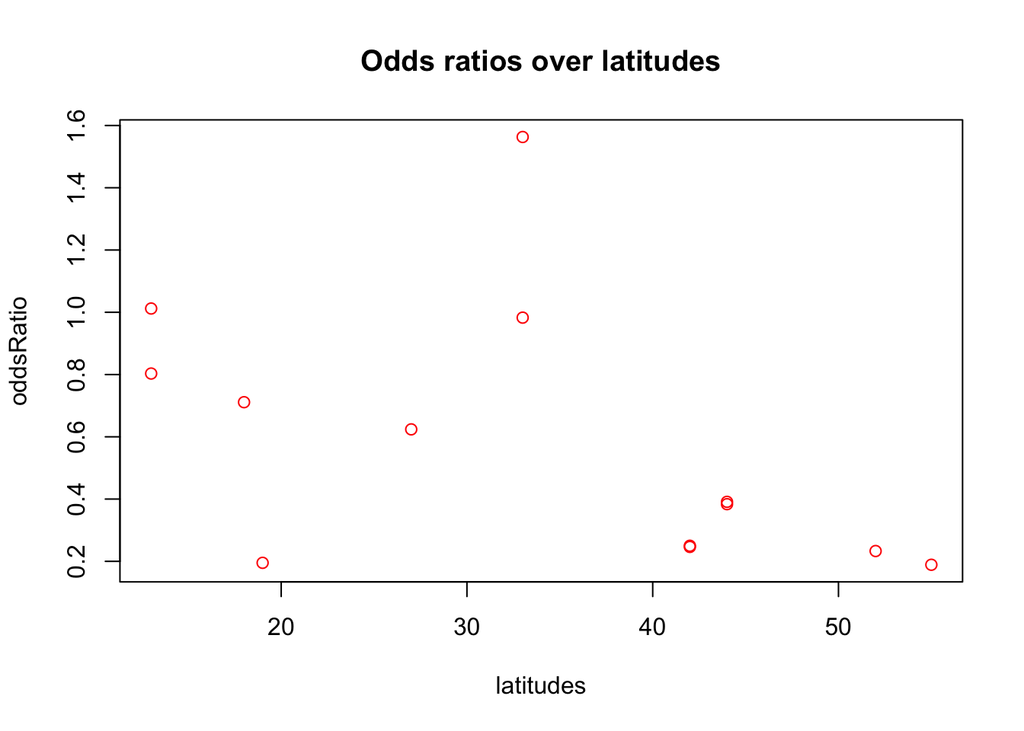

> In this graph, we can see a negative relation between latitudes and odds ratios, with some outliers. The latitudes represent the distance from the equator. Therefore, the closer the place is to the equator, that is, the hotter it is, the higher the odds of the having TB having recieved a vaccine.

After evaluating the graph, it is seen that the value fo the odds ratio is generally less than 1. This means that the odds of a TB patient, getting vaccinated are less than the odds a TB patient not getting vaccinated. Therefore, *generally*, the BCG vaccination is effective in preventing Tuberculosis.

**Relationship between Odds Ratios and Relative Risk**

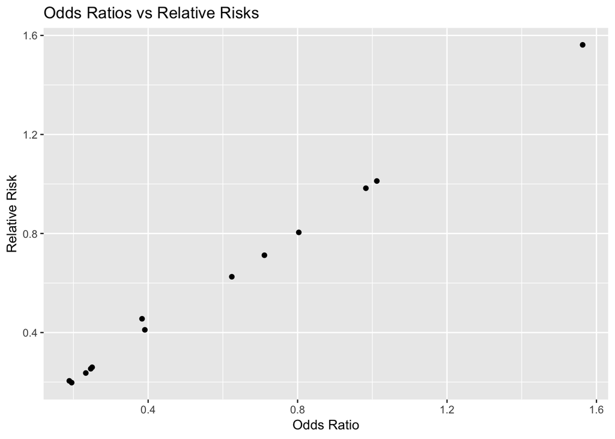

> The graph above represents a scatter plot of the relationship between odds ratios and relative risks for all 13 studies. They show a very strogn positive correlation. This is because both are different ways of measuring risks.

## Low Birth Weight

This part of the assignment uses the **birthwt** dataset from the **MASS** package. It contains information about the mothers of children, and the birth-weight of those children. Upon analyzing the data further, I found:

The table below shows the relative risks of having a low-birth weight infant based on different input variables.

| Exposure | Relative Risk |
| --- | --- |
| Smoking Status | 1.6076421 |
| Hypertension Status | 1.9855769 |
| Attending 0 prenatal care visits | 1.3930435 |
| Giving birth before age 20 | 0.9224599 |